# `cpam`: an introductory example

Luke Yates

2025-02-24

## About

This tutorial demonstrates the R package `cpam` for the analysis of time series omics data. It serves as a basic introduction to the package. There are also two detailed case studies using real world data:

- [Arabisdopsis Case Study](https://raw.githack.com/l-a-yates/cpam_manuscript/main/R/torre.html)
- [Human embryo Case Study](https://raw.githack.com/l-a-yates/cpam_manuscript/main/R/crisp.html)

These case studies and several simulation studies are presented in the accompanying [manuscript](https://doi.org/10.1101/2024.12.22.630003) by Yates et al. (2024).

## Data

The data for the following examples have been simulated based on empirical RNA-seq data. These data are gene-level counts from a case-only experiment with 6 time points and 5 replicates per time point. The code to reproduce the data is available in this repository `R/simulate_counts_example.R`.

## Installation

You can install `cpam` from GitHub using:

```r
devtools::install_github("l-a-yates/cpam")
```

# Getting started

## Load packages

```r
library(cpam)
library(dplyr)
library(readr)
library(tidyr)
library(stringr)
library(ggplot2)
```

## Experimental design

The experimental design for this example loads is included in the `cpam` package. Simply type the folowing to see the design.

```r
exp_design_example
```

| sample | time |
| --- | --- |
| X1 | 1 |
| X2 | 1 |
| X3 | 1 |
| X4 | 1 |
| X5 | 1 |
| X6 | 2 |
| X7 | 2 |
| X8 | 2 |
| X9 | 2 |
| X10 | 2 |

[output cut: 20 more lines]

## Count matrix

The count data for this example are provided as a matrix. Let’s take a look at the first few rows.

```r
# convert to tibble (for display only)
as.data.frame(count_matrix_example) %>% head %>% tibble::rownames_to_column("target_id")
```

| target_id | X1 | X2 | X3 | X4 | X5 | X6 | X7 | X8 | X9 | X10 | X11 | X12 | X13 | X14 | X15 | X16 | X17 | X18 | X19 | X20 | X21 | X22 | X23 | X24 | X25 | X26 | X27 | X28 | X29 | … |
| --- | --- | --- | --- | --- | --- | --- | --- | --- | --- | --- | --- | --- | --- | --- | --- | --- | --- | --- | --- | --- | --- | --- | --- | --- | --- | --- | --- | --- | --- | --- |
| g001 | 100702 | 93137 | 100748 | 90302 | 95962 | 79708 | 89726 | 85350 | 94282 | 121842 | 102158 | 90054 | 103692 | 78474 | 80961 | 81403 | 76614 | 87686 | 81953 | 106238 | 87308 | 83021 | 81013 | 95695 | 109277 | 97975 | 79013 | 88479 | 119039 | … |
| g002 | 8654 | 7926 | 8930 | 9196 | 8882 | 7993 | 8479 | 9865 | 8015 | 7060 | 9523 | 7124 | 9004 | 7840 | 10012 | 8161 | 8789 | 9250 | 8816 | 7514 | 9565 | 7690 | 8946 | 7980 | 8919 | 9059 | 8227 | 7858 | 9253 | … |
| g003 | 3258 | 3131 | 3024 | 3507 | 3687 | 2419 | 2456 | 2553 | 2238 | 2588 | 2250 | 2098 | 2166 | 1884 | 2339 | 1807 | 1961 | 1791 | 1763 | 1893 | 1577 | 1505 | 1628 | 1511 | 1757 | 1573 | 1512 | 1659 | 1514 | … |
| g004 | 24572 | 18575 | 28039 | 27230 | 25244 | 24315 | 26200 | 24790 | 26165 | 22652 | 24722 | 20735 | 27313 | 30438 | 26432 | 25533 | 23079 | 27307 | 24375 | 26901 | 27090 | 28163 | 26881 | 26964 | 23837 | 24079 | 21432 | 23805 | 21358 | … |
| g005 | 125565 | 118382 | 115517 | 105728 | 114457 | 120633 | 115978 | 108458 | 113169 | 115742 | 132714 | 121729 | 96647 | 134781 | 123007 | 124228 | 126771 | 110148 | 95926 | 105201 | 100622 | 110298 | 145240 | 129146 | 114071 | 132796 | 125034 | 124525 | 115182 | … |
| g006 | 1988 | 2058 | 2530 | 2135 | 2131 | 2139 | 2043 | 2068 | 2298 | 2281 | 2021 | 2097 | 2237 | 1951 | 1970 | 2175 | 1990 | 2035 | 2295 | 2051 | 2159 | 1792 | 2003 | 2190 | 2140 | 2130 | 2281 | 2036 | 2241 | … |

## Fitting `cpam`

To fit the models, we first prepare the `cpam` object, then compute p-values, estimate changepoints, and select the shape for each gene In this simple example, the simulated data are gene-level, that is we do not have isoform-level counts. As such, we leave NULL the transcript-to-gene mapping (`t2g`) and we set `gene_level = T`.

```r
  cpo <- prepare_cpam(exp_design = exp_design_example,
                      count_matrix = count_matrix_example,
                      model_type = "case-only",
                      t2g = NULL,
                      gene_level = T,
                      num_cores = 4)
  cpo <- compute_p_values(cpo) # 6 seconds
  cpo <- estimate_changepoint(cpo) # 4 seconds
  cpo <- select_shape(cpo) # 5 seconds
```

We can look at a summary of the fitted cpam object

```r
cpo
## cpam object
## -----------
## case-only time series
## 30 samples
## 6 time points
## Counts aggregated for gene-level inference
```

Although it cannot be launched here within the online tutorial, you can launch the Shiny app on your own computer to visualise the results interactively using `visualise(cpo)`.

## Result tables

The results of the analysis are summarised using the `results` function.

```r
results(cpo)
```

| target_id | p | cp | shape | lfc.1 | lfc.2 | lfc.3 | lfc.4 | lfc.5 | lfc.6 | counts.1 | counts.2 | counts.3 | counts.4 | counts.5 | counts.6 |
| --- | --- | --- | --- | --- | --- | --- | --- | --- | --- | --- | --- | --- | --- | --- | --- |
| g003 | 9.262545e-319 | 1 | mdcx | 0 | -0.3487989 | -0.6342337 | -0.85630888 | -1.015028149 | -1.11039238 | 3267.33219 | 2565.63195 | 2105.08643 | 1804.75658 | 1616.73698 | 1513.32386 |
| g013 | 9.262545e-319 | 3 | ilin | 0 | 0.0000000 | 0.0000000 | 0.32741484 | 0.654829684 | 0.98224453 | 18661.90610 | 18661.90610 | 18661.90610 | 23416.26845 | 29381.86620 | 36867.27727 |
| g055 | 9.262545e-319 | 1 | ilin | 0 | 0.1946137 | 0.3892274 | 0.58384104 | 0.778454716 | 0.97306840 | 607.79401 | 695.57020 | 796.02283 | 910.98260 | 1042.54458 | 1193.10644 |
| g063 | 9.262545e-319 | 1 | cv | 0 | 0.5948901 | 0.9366704 | 1.02534244 | 0.860909970 | 0.44337669 | 6172.16226 | 9322.17176 | 11814.16984 | 12563.08118 | 11209.77922 | 8392.80278 |
| g069 | 9.262545e-319 | 2 | ilin | 0 | 0.0000000 | 0.2254776 | 0.45095529 | 0.676432933 | 0.90191058 | 67904.30942 | 67904.30942 | 79391.29227 | 92821.46217 | 108523.53694 | 126881.84171 |
| g090 | 9.262545e-319 | 2 | ilin | 0 | 0.0000000 | 0.2385577 | 0.47711548 | 0.715673219 | 0.95423096 | 32.83757 | 32.83757 | 38.74217 | 45.70851 | 53.92747 | 63.62431 |
| g106 | 9.262545e-319 | 1 | mdcx | 0 | -0.4703372 | -0.7777797 | -0.89248001 | -0.902470085 | -0.90247027 | 30076.09018 | 21708.79785 | 17542.29289 | 16201.60822 | 16089.80618 | 16089.80412 |
| g126 | 9.262545e-319 | 1 | ilin | 0 | 0.2249246 | 0.4498492 | 0.67477381 | 0.899698419 | 1.12462302 | 4016.85573 | 4694.56424 | 5486.61314 | 6412.29350 | 7494.15110 | 8758.53557 |
| g128 | 9.262545e-319 | 1 | ilin | 0 | 0.2091781 | 0.4183562 | 0.62753426 | 0.836712342 | 1.04589043 | 38098.58793 | 44043.08765 | 50915.10408 | 58859.35709 | 68043.14711 | 78659.87835 |
| g129 | 9.262545e-319 | 1 | cv | 0 | 0.6257326 | 0.9785615 | 1.11304090 | 1.075945070 | 0.88816411 | 258.74149 | 399.23663 | 509.85002 | 559.66066 | 545.45361 | 478.88377 |

[output cut: 94 more lines]

```r
results(cpo, min_count = 10, min_lfc = 1, p_threshold = 0.01)
```

| target_id | p | cp | shape | lfc.1 | lfc.2 | lfc.3 | lfc.4 | lfc.5 | lfc.6 | counts.1 | counts.2 | counts.3 | counts.4 | counts.5 | counts.6 |
| --- | --- | --- | --- | --- | --- | --- | --- | --- | --- | --- | --- | --- | --- | --- | --- |
| g063 | 9.262545e-319 | 1 | cv | 0 | 0.5948901 | 0.9366704 | 1.02534244 | 0.8609100 | 0.4433767 | 6172.16226 | 9322.17176 | 11814.16984 | 12563.08118 | 11209.77922 | 8392.80278 |
| g126 | 9.262545e-319 | 1 | ilin | 0 | 0.2249246 | 0.4498492 | 0.67477381 | 0.8996984 | 1.1246230 | 4016.85573 | 4694.56424 | 5486.61314 | 6412.29350 | 7494.15110 | 8758.53557 |
| g128 | 9.262545e-319 | 1 | ilin | 0 | 0.2091781 | 0.4183562 | 0.62753426 | 0.8367123 | 1.0458904 | 38098.58793 | 44043.08765 | 50915.10408 | 58859.35709 | 68043.14711 | 78659.87835 |
| g129 | 9.262545e-319 | 1 | cv | 0 | 0.6257326 | 0.9785615 | 1.11304090 | 1.0759451 | 0.8881641 | 258.74149 | 399.23663 | 509.85002 | 559.66066 | 545.45361 | 478.88377 |
| g171 | 9.262545e-319 | 1 | cv | 0 | 0.5932023 | 0.9223741 | 1.01283317 | 0.9005742 | 0.6163178 | 4950.11769 | 7467.70599 | 9381.61880 | 9988.69351 | 9240.92373 | 7588.32058 |
| g186 | 9.262545e-319 | 1 | cx | 0 | -0.2333560 | -0.3235506 | -0.20905145 | 0.2188971 | 1.0526213 | 19739.98690 | 16791.89486 | 15774.23959 | 17077.17792 | 22974.25630 | 40946.56118 |
| g331 | 9.262545e-319 | 3 | ilin | 0 | 0.0000000 | 0.0000000 | 0.33921584 | 0.6784317 | 1.0176475 | 36.95634 | 36.95634 | 36.95634 | 46.75232 | 59.14490 | 74.82236 |
| g334 | 9.262545e-319 | 1 | micv | 0 | 0.4018641 | 0.6917524 | 0.88626982 | 1.0047222 | 1.0624637 | 2797.72649 | 3696.39514 | 4519.01171 | 5171.29193 | 5613.79785 | 5843.03792 |
| g341 | 9.262545e-319 | 1 | cx | 0 | -0.4649112 | -0.5925479 | -0.38290350 | 0.1640289 | 1.0482532 | 23680.72255 | 17157.05504 | 15704.36108 | 18160.57146 | 26532.15813 | 48972.31257 |
| g393 | 9.262545e-319 | 1 | cv | 0 | 0.4323240 | 0.7471940 | 0.94460072 | 1.0245280 | 0.9869604 | 931.78735 | 1257.35901 | 1564.02833 | 1793.37025 | 1895.52910 | 1846.80690 |

[output cut: 12 more lines]

## Plotting genes and transcripts

A single gene can be plotted using the `plot_cpam` function. Here we plot the gene g063

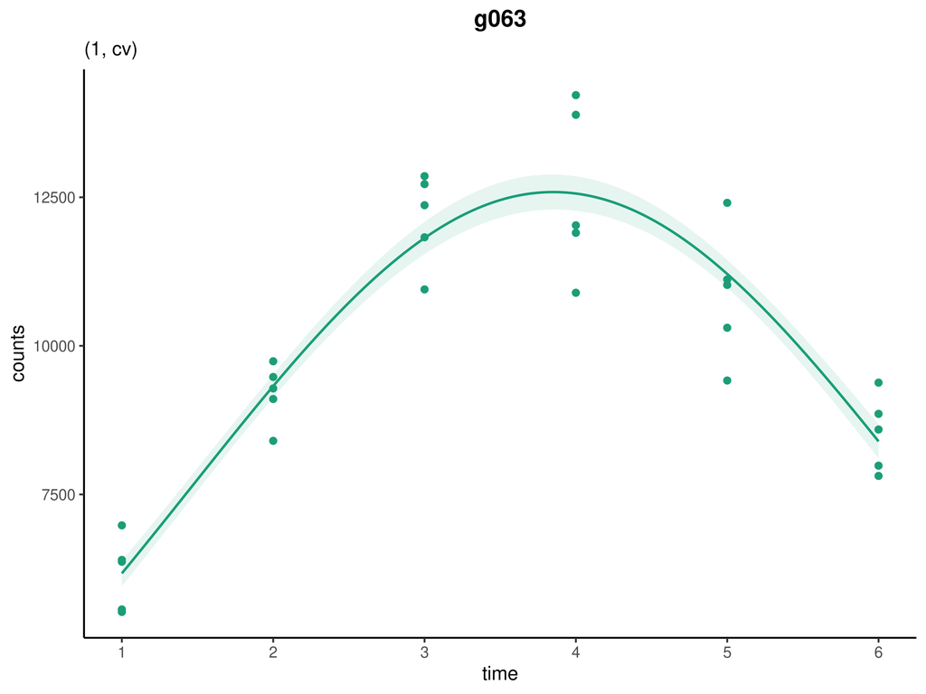

```r
plot_cpam(cpo, gene_id = "g063")
```

Let’s look for a gene that has a more complex trend. Unconstrained shapes in `cpam` are denoted by `'tp'`. We can filter the results for genes with unconstrained shapes and plot one of them.

```r
results(cpo) %>%
  filter(shape == "tp")
```

| target_id | p | cp | shape | lfc.1 | lfc.2 | lfc.3 | lfc.4 | lfc.5 | lfc.6 | counts.1 | counts.2 | counts.3 | counts.4 | counts.5 | counts.6 |
| --- | --- | --- | --- | --- | --- | --- | --- | --- | --- | --- | --- | --- | --- | --- | --- |
| g210 | 9.262545e-319 | 1 | tp | 0 | 0.6392517 | 0.8347098 | 0.66199867 | 0.6243213 | 0.84206195 | 62935.8845 | 98023.967 | 112246.0377 | 99581.7598 | 97014.7552 | 112819.5192 |
| g325 | 9.262545e-319 | 1 | tp | 0 | -0.8970277 | -0.8822846 | -0.15693398 | 0.2092847 | -0.08913828 | 68092.4954 | 36565.121 | 36940.6988 | 61074.1478 | 78722.7425 | 64012.6716 |
| g335 | 9.262545e-319 | 1 | tp | 0 | 0.2519239 | 0.3111818 | 0.24016134 | 0.4543603 | 0.97987562 | 1154.4531 | 1374.716 | 1432.3572 | 1363.5531 | 1581.8029 | 2276.9225 |
| g339 | 9.262545e-319 | 1 | tp | 0 | -0.7559925 | -0.7772115 | -0.30624356 | -0.3678297 | -0.91408171 | 4363.3260 | 2583.695 | 2545.9723 | 3528.8172 | 3381.3483 | 2315.5366 |
| g399 | 9.262545e-319 | 1 | tp | 0 | 0.2483345 | 0.4866353 | 0.70509583 | 0.8749339 | 1.00797318 | 3916.1027 | 4651.684 | 5487.1380 | 6384.2379 | 7181.8347 | 7875.6105 |
| g400 | 9.262545e-319 | 1 | tp | 0 | -0.9166212 | -0.6743465 | 0.55843871 | 0.7062251 | -0.26989910 | 9730.7664 | 5154.856 | 6097.4537 | 14330.2527 | 15876.0331 | 8070.4792 |
| g417 | 9.262545e-319 | 1 | tp | 0 | -0.4254884 | -0.5744064 | -0.53110347 | -0.7105421 | -0.98322598 | 7234.9480 | 5387.045 | 4858.7200 | 5006.7665 | 4421.2079 | 3659.7794 |
| g424 | 9.262545e-319 | 1 | tp | 0 | -0.3248004 | -0.2265697 | 0.04423327 | -0.2038454 | -0.90537893 | 9559.3838 | 7632.296 | 8170.0672 | 9857.0155 | 8299.7749 | 5103.6829 |
| g640 | 9.262545e-319 | 1 | tp | 0 | 0.5747457 | 0.7667530 | 0.39499918 | 0.4974603 | 0.92100016 | 1043.3120 | 1553.925 | 1775.1288 | 1371.8948 | 1472.8710 | 1975.4357 |
| g715 | 9.262545e-319 | 1 | tp | 0 | 0.8359302 | 0.8100431 | -0.23898464 | -0.6799945 | -0.33218635 | 157101.1836 | 280426.807 | 275439.8130 | 133118.3457 | 98057.4806 | 124790.4650 |

[output cut: 4 more lines]

We plot the first gene in the list.

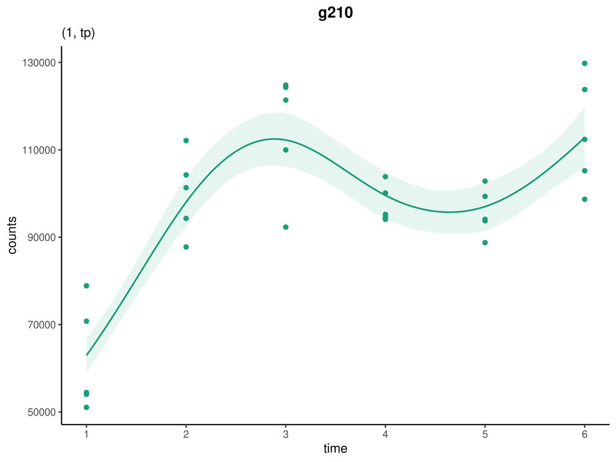

```r
plot_cpam(cpo, gene_id = "g210")
```

This selection of `'tp'` suggests that the trend for this gene does not conform to one of the simpler shape types that `cpam` uses. We can exclude `'tp'` as an option and force `cpam` to choose among the simpler forms by setting `shape_type = "shape2"` in the `plot_cpam` function (`"shape1"`, the default, allows the `'tp'`). This choice can be useful for analysis such as clustering. For example:

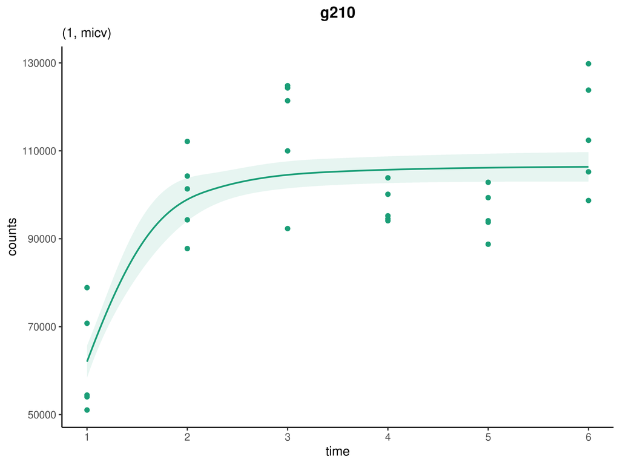

```r
plot_cpam(cpo, gene_id = "g210",shape_type = "shape2")
```

Here a monotonic increasing concave shape (‘micv’) is chosen, and we can see this trend deviates from the data substantially more that the unconstrained shape. See the [manuscript](https://doi.org/10.1101/2024.12.22.630003) for more details on the shape types available in `cpam`.

Next we look for a gene with a changepoint by filtering for genes with changepoints at the third time point.

```r
results(cpo) %>%
  filter(cp == 3)
```

| target_id | p | cp | shape | lfc.1 | lfc.2 | lfc.3 | lfc.4 | lfc.5 | lfc.6 | counts.1 | counts.2 | counts.3 | counts.4 | counts.5 | counts.6 |
| --- | --- | --- | --- | --- | --- | --- | --- | --- | --- | --- | --- | --- | --- | --- | --- |
| g013 | 9.262545e-319 | 3 | ilin | 0 | 0 | 0 | 0.3274148 | 0.6548297 | 0.9822445 | 18661.90610 | 18661.90610 | 18661.90610 | 23416.26845 | 29381.8662 | 36867.27727 |
| g146 | 9.262545e-319 | 3 | dlin | 0 | 0 | 0 | -0.3292578 | -0.6585156 | -0.9877735 | 167.79910 | 167.79910 | 167.79910 | 133.55900 | 106.3057 | 84.61360 |
| g187 | 9.262545e-319 | 3 | dlin | 0 | 0 | 0 | -0.4193064 | -0.8386128 | -1.2579192 | 18215.95952 | 18215.95952 | 18215.95952 | 13621.60387 | 10186.0180 | 7616.94175 |
| g297 | 9.262545e-319 | 3 | ilin | 0 | 0 | 0 | 0.3081235 | 0.6162471 | 0.9243706 | 9799.42913 | 9799.42913 | 9799.42913 | 12132.63691 | 15021.3728 | 18597.90609 |
| g304 | 9.262545e-319 | 3 | cx | 0 | 0 | 0 | -1.0422935 | -0.6516829 | 0.8830248 | 3130.49922 | 3130.49922 | 3130.49922 | 1520.02941 | 1992.6797 | 5773.38555 |
| g331 | 9.262545e-319 | 3 | ilin | 0 | 0 | 0 | 0.3392158 | 0.6784317 | 1.0176475 | 36.95634 | 36.95634 | 36.95634 | 46.75232 | 59.1449 | 74.82236 |
| g559 | 9.262545e-319 | 3 | ilin | 0 | 0 | 0 | 0.2922005 | 0.5844010 | 0.8766014 | 443.52215 | 443.52215 | 443.52215 | 543.09578 | 665.0243 | 814.32664 |
| g623 | 9.262545e-319 | 3 | micv | 0 | 0 | 0 | 0.3169463 | 0.6338925 | 0.9508388 | 328.57435 | 328.57435 | 328.57435 | 409.30212 | 509.8640 | 635.13296 |
| g634 | 9.262545e-319 | 3 | cx | 0 | 0 | 0 | -0.8798729 | -1.1330087 | -0.7594075 | 12547.39069 | 12547.39069 | 12547.39069 | 6818.44429 | 5721.1563 | 7412.23147 |
| g652 | 9.262545e-319 | 3 | ilin | 0 | 0 | 0 | 0.3629876 | 0.7259753 | 1.0889629 | 13015.63847 | 13015.63847 | 13015.63847 | 16739.23639 | 21528.1053 | 27687.00469 |

[output cut: 3 more lines]

Again, we plot the first gene in the list.

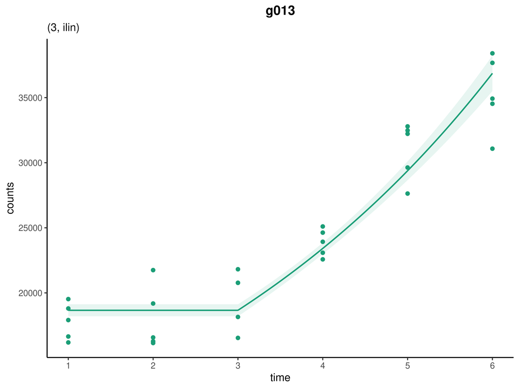

```r
plot_cpam(cpo, gene_id = "g013")
```

## Clusters

The results function can be used to generate clusters according to selected filters. The `plot_cluster` function can then be used to visualise the clusters. With such a small simulated data set, we don’t have many genes in each cluster, but we can try a few different clustering options to get an idea of how the function works.

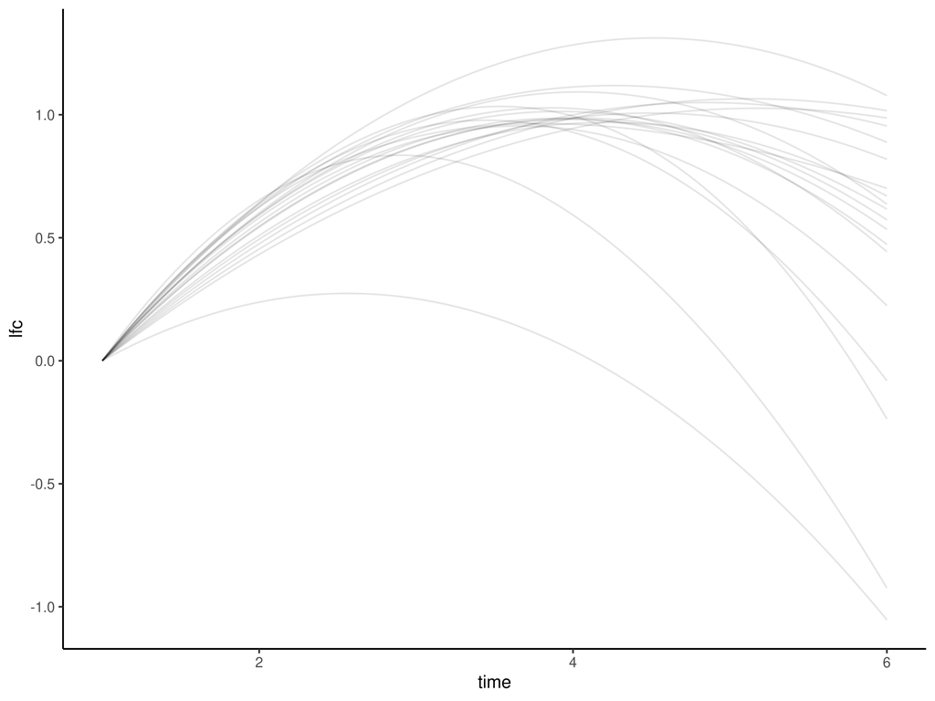

```r
res <- results(cpo)
plot_cluster(cpo, res, changepoints = 1, shapes = c("cv"))
```

There are 19 genes with a concave shape and a changepoint at the first time point.

More than one shape or changepoint can be provided. For example:

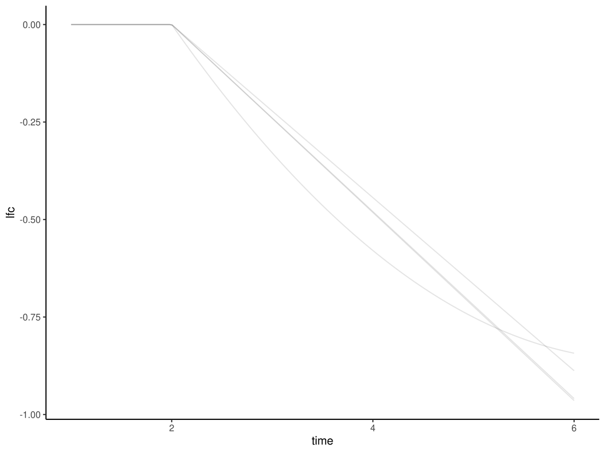

```r
plot_cluster(cpo, res, changepoints = 2, shapes = c("dlin","mdcx"))
```

There are just four genes with decreasing linear or monotonic decreasing convex shapes which have a changepoint at the second time point.

Clustering can be further refined based on, for example, the rate at which the above transcripts attain their maximum values. We illustrate advanced refinements such as this [case study](https://raw.githack.com/l-a-yates/cpam_manuscript/main/R/torre.html).

## Many more options

This is just a simple example to get you started. The package has many more features and options. Check out the two case studies to see how `cpam` can be used to analyse real-world data:

- [Arabidopsis Case Study](https://raw.githack.com/l-a-yates/cpam_manuscript/main/R/torre.html)
- [Human Embryo Case Study](https://raw.githack.com/l-a-yates/cpam_manuscript/main/R/crisp.html)

Yates, Luke A., Jazmine L. Humphreys, Michael A. Charleston, and Steven M. Smith. 2024. “Shape-Constrained, Changepoint Additive Models for Time Series Omics Data with cpam,” December. https://doi.org/10.1101/2024.12.22.630003.